# Análise Exploratória de Dados da Educação Superior em R

```r
glimpse(tecnicos) # Verificar a estrutura
```

```
Rows: 2,561
Columns: 15
$ QT_TEC_TOTAL                   <int> 1297, 3051, 1759, 1358, 1235, 729, 957, 1899, 634, 926, 394, …
$ QT_TEC_FUNDAMENTAL_INCOMP_FEM  <int> 8, 1, 0, 4, 2, 4, 10, 4, 0, 0, 0, 0, 10, 1, 4, 2, 0, 3, 32, 1…
$ QT_TEC_FUNDAMENTAL_INCOMP_MASC <int> 1, 0, 21, 1, 10, 24, 19, 57, 1, 1, 4, 6, 7, 1, 23, 27, 0, 6, …
$ QT_TEC_FUNDAMENTAL_COMP_FEM    <int> 2, 2, 7, 2, 1, 2, 7, 0, 1, 1, 7, 0, 4, 1, 3, 6, 0, 2, 44, 50,…
$ QT_TEC_FUNDAMENTAL_COMP_MASC   <int> 9, 20, 12, 8, 18, 26, 9, 13, 0, 3, 8, 2, 14, 0, 20, 19, 4, 3,…
$ QT_TEC_MEDIO_FEM               <int> 21, 96, 141, 44, 122, 18, 6, 12, 145, 183, 48, 31, 159, 260, …
$ QT_TEC_MEDIO_MASC              <int> 57, 113, 114, 53, 151, 55, 36, 205, 166, 129, 70, 52, 77, 213…
$ QT_TEC_SUPERIOR_FEM            <int> 66, 207, 309, 99, 70, 37, 53, 89, 46, 265, 87, 68, 354, 145, …
$ QT_TEC_SUPERIOR_MASC           <int> 84, 225, 242, 144, 84, 66, 72, 141, 79, 146, 66, 61, 163, 92,…
$ QT_TEC_ESPECIALIZACAO_FEM      <int> 338, 777, 268, 358, 241, 91, 180, 271, 100, 102, 47, 220, 115…
$ QT_TEC_ESPECIALIZACAO_MASC     <int> 329, 709, 181, 265, 207, 119, 165, 516, 9, 54, 31, 150, 31, 3…
$ QT_TEC_MESTRADO_FEM            <int> 179, 416, 221, 180, 143, 113, 143, 246, 25, 20, 5, 186, 22, 2…
$ QT_TEC_MESTRADO_MASC           <int> 116, 274, 135, 128, 103, 99, 106, 196, 35, 16, 19, 114, 17, 2…
$ QT_TEC_DOUTORADO_FEM           <int> 56, 130, 66, 38, 46, 47, 84, 86, 8, 4, 2, 125, 11, 10, 1, 121…
$ QT_TEC_DOUTORADO_MASC          <int> 31, 81, 42, 34, 37, 28, 67, 63, 19, 2, 0, 47, 7, 14, 0, 77, 0…
```

```r
total_servidores <- sum(tecnicos$QT_TEC_TOTAL)
print((total_servidores))
```

```
[1] 350752
```

```r
total_feminino <- tecnicos %>%
  select(ends_with('_FEM')) %>%
  as.matrix() %>%
  sum()

total_masculino <- tecnicos %>%
  select(ends_with('_MASC')) %>%
  as.matrix() %>%
  sum()
```

```r
 # Criando dataframe para o gráfico de pizza
dados_totais <- data.frame(
  genero = c("Feminino", "Masculino"),
  quantidade = c(total_feminino, total_masculino)
) %>%
  mutate(
    porcentagem = (quantidade / sum(quantidade)) * 100
  )

print(dados_totais)
```

| genero | quantidade | porcentagem |
| --- | --- | --- |
| Feminino | 194439 | 55.43489 |
| Masculino | 156313 | 44.56511 |

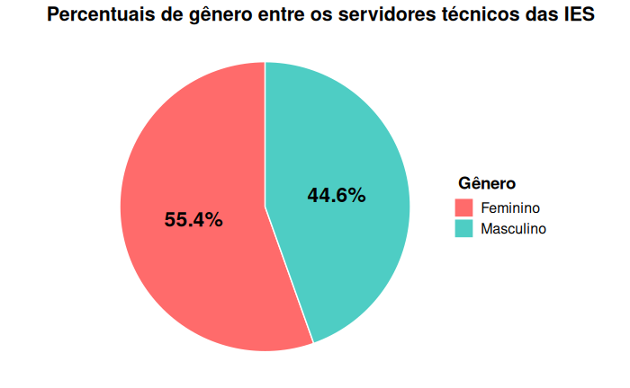

```r
 # Gráficos porcentagem de servidores de acordo com o gênero

ggplot(dados_totais, aes(x = "", y = porcentagem, fill = genero)) +
  geom_bar(stat = "identity", width = 1, color = "white") +
  coord_polar("y", start = 0) +
  geom_text(aes(label = paste0(round(porcentagem, 1), "%")),
            position = position_stack(vjust = 0.5),
            color = "black", size = 6, fontface = "bold") +
  labs(title = "Percentuais de gênero entre os servidores técnicos das IES",
       fill = " Gênero") +
  scale_fill_manual(values = c("#FF6B6B", "#4ECDC4")) +
  theme_void() +
  theme(legend.position = "right",
        legend.text = element_text(size = 12),
        legend.title = element_text(size = 14, face = 'bold'),
        plot.title = element_text(size = 16, face = 'bold', hjust = 0.2)

        )
```

Do total de 350752 dos servidores técnicos das IES, 194439 (55,43%) são do gênero feminino e 156313 (44,56%) do gênero masculino, portanto existe um número significativo a mais de mulheres que homens.

```r
# Método 1: Especificando explicitamente os nomes das colunas
dados_escolaridade <- tecnicos %>%
  summarise(
    # Fundamental Incompleto
    Fund_Incomp_FEM = sum(QT_TEC_FUNDAMENTAL_INCOMP_FEM),
    Fund_Incomp_MASC = sum(QT_TEC_FUNDAMENTAL_INCOMP_MASC),

    # Fundamental Completo
    Fund_Comp_FEM = sum(QT_TEC_FUNDAMENTAL_COMP_FEM),
    Fund_Comp_MASC = sum(QT_TEC_FUNDAMENTAL_COMP_MASC),

    # Médio
    Medio_FEM = sum(QT_TEC_MEDIO_FEM),
    Medio_MASC = sum(QT_TEC_MEDIO_MASC),

    # Superior
    Superior_FEM = sum(QT_TEC_SUPERIOR_FEM),
    Superior_MASC = sum(QT_TEC_SUPERIOR_MASC),

    # Especialização
    Especializacao_FEM = sum(QT_TEC_ESPECIALIZACAO_FEM),
    Especializacao_MASC = sum(QT_TEC_ESPECIALIZACAO_MASC),

    # Mestrado
    Mestrado_FEM = sum(QT_TEC_MESTRADO_FEM),
    Mestrado_MASC = sum(QT_TEC_MESTRADO_MASC),

    # Doutorado
    Doutorado_FEM = sum(QT_TEC_DOUTORADO_FEM),
    Doutorado_MASC = sum(QT_TEC_DOUTORADO_MASC)
  ) %>%
  pivot_longer(
    everything(),
    names_to = "categoria",
    values_to = "quantidade"
  ) %>%
  mutate(
    # Extrair gênero (última parte após o último underscore) se FEM for true vai pro feminino, se não for masculino
    genero = ifelse(grepl("_FEM$", categoria), "Feminino", "Masculino"),

    # Extrair escolaridade, removendo FEM E MASC
    escolaridade = gsub("_FEM$|_MASC$", "", categoria),

    # Ajustar os nomes das escolaridades
    escolaridade = case_when(
      escolaridade == "Fund_Incomp" ~ "Fund. Incompleto",
      escolaridade == "Fund_Comp" ~ "Fund. Completo",
      escolaridade == "Medio" ~ "Médio",
      escolaridade == "Superior" ~ "Superior",
      escolaridade == "Especializacao" ~ "Especialização",
      escolaridade == "Mestrado" ~ "Mestrado",
      escolaridade == "Doutorado" ~ "Doutorado"
    ),
    escolaridade = factor(escolaridade,
                         levels = c("Fund. Incompleto", "Fund. Completo", "Médio",
                                  "Superior", "Especialização", "Mestrado", "Doutorado"))
  ) %>%
  select(escolaridade, genero, quantidade)

print(dados_escolaridade)
```

| escolaridade | genero | quantidade |
| --- | --- | --- |
| Fund. Incompleto | Feminino | 2410 |
| Fund. Incompleto | Masculino | 4032 |
| Fund. Completo | Feminino | 4444 |
| Fund. Completo | Masculino | 6236 |
| Médio | Feminino | 48159 |
| Médio | Masculino | 44147 |
| Superior | Feminino | 51223 |
| Superior | Masculino | 38349 |
| Especialização | Feminino | 52145 |
| Especialização | Masculino | 37300 |

[output cut: 4 more lines]

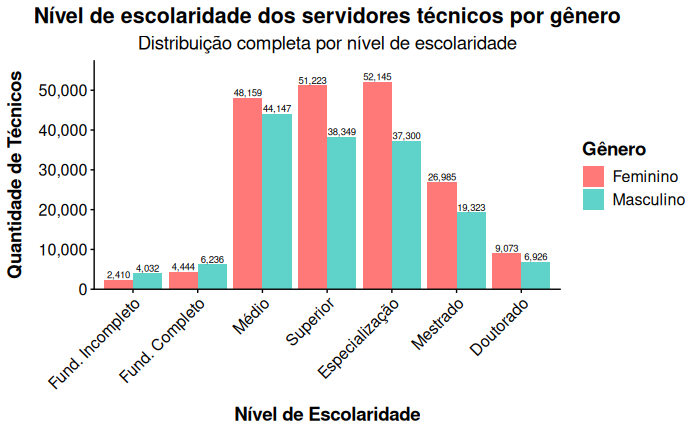

```r
ggplot(dados_escolaridade, aes(x = escolaridade, y = quantidade, fill = genero)) +
  geom_col(position = "dodge", alpha = 0.9) +
  geom_text(aes(label = scales::comma(quantidade)),
            position = position_dodge(width = 0.9),
            vjust = -0.2, size = 2.5) +
  labs(title = "Nível de escolaridade dos servidores técnicos por gênero",
       subtitle = "Distribuição completa por nível de escolaridade",
       x = "Nível de Escolaridade",
       y = "Quantidade de Técnicos",
       fill = "Gênero") +
  scale_fill_manual(values = c("#FF6B6B", "#4ECDC4")) +
  scale_y_continuous(labels = scales::comma, expand = expansion(mult = c(0, 0.1))) +
  theme_classic() +
  theme(axis.text.x = element_text(angle = 45, hjust = 1, size = 12),
        axis.text.y = element_text(size = 12),
        legend.position = "right",
        legend.text = element_text(size = 12),
        legend.title = element_text(size = 14, face = 'bold'),
        plot.title = element_text(size = 16, face = 'bold', hjust = 0.5),
        plot.subtitle = element_text(size = 14, hjust = 0.5),
        axis.title.x = element_text(face = "bold", size = 14, margin = margin(t = 10)),
        axis.title.y = element_text(face = "bold", size = 14, margin = margin(r = 10)),
                  )
```

A partir da análise do gráfico acima, pode-se observar que as mulheres são maioria no ensino médio e nos níveis superiores, indicando que essas possuem um perfil de escolarização mais elevado que os homens. Os homens são maioria apenas nos níveis de ensino fundamental (incompleto e completo).

```r
porcentagem_escolaridade_geral <- dados_escolaridade %>% group_by(escolaridade) %>%
  summarise(Total = sum(quantidade)) %>% mutate(Porcentagem = round((Total / sum(Total)) * 100, 2))


porcentagem_escolaridade_geral %>%
  kable(format = "html",
       caption = "<div style='text-align: center; font-size: 18px; font-weight: bold;'>DISTRIBUIÇÃO GERAL POR NÍVEL DE ESCOLARIDADE</div>",
          col.names = c("Escolaridade", "Total", "Porcentagem (%)")) %>%  column_spec(1:3, extra_css = "text-align: center;") %>%  kable_styling(
          bootstrap_options = c("striped", "hover"),
          full_width = FALSE
        ) %>%
  row_spec(0, bold = TRUE, font_size = 16)
```

[output not shown]

# Gráfico da distribuição geral dos tecnicos por nível de escolaridade

```r
ggplot(porcentagem_escolaridade_geral, aes(x = escolaridade, y = Porcentagem, fill = escolaridade)) +
  geom_col(position = "dodge", alpha = 0.9) +
  labs(title = "Distribuição de nível de escolaridade entre os técnicos",
       x = "Nível de Escolaridade",
       y = "Porcentagem de Técnicos",
       fill = 'Nível de escolaridade') +
    theme_classic() +
    theme(axis.text.x = element_text(angle = 45, hjust = 1, size = 12),
        axis.text.y = element_text(size = 12),
        legend.position = "none",
        legend.text = element_text(size = 12),
        legend.title = element_text(size = 14, face = 'bold'),
        plot.title = element_text(size = 16, face = 'bold', hjust = 0.5),
        axis.title.x = element_text(face = "bold", size = 14, margin = margin(t = 10)),
        axis.title.y = element_text(face = "bold", size = 14, margin = margin(r = 10)),
                  )
```

[output not shown]

[output not shown]

Com base nos dados da distribuição geral por nível de escolaridade, observa-se que a maior parte dos servidores técnicos possui formação de nível médio (26,32%), seguida de perto por Superior (25,54%) e Especialização (25,50%), formando juntos um contingente de 77,36% do total. Chama atenção a expressiva qualificação acadêmica do grupo, com 43,26% possuindo pós-graduação (Especialização, Mestrado ou Doutorado). Em contraste, apenas 4,88% estão nos níveis fundamental (incompleto ou completo), indicando um perfil educacional bastante elevado entre os técnicos.

# Quantidade de técnicos por instituição pública e privada

```r
# Seleção das colunas necessárias
tec_inst <- dados %>% select(TP_REDE, QT_TEC_TOTAL) %>% rename(total_de_tecnicos = QT_TEC_TOTAL,
                                                               tipo_de_rede = TP_REDE)

# Modificando o data frame
tec_inst_g <- tec_inst  %>%
  mutate(
    tipo_de_rede = case_when(
      tipo_de_rede == 1 ~ "Pública",
      tipo_de_rede == 2 ~ "Privada",
      TRUE ~ "Outro")) %>% group_by(tipo_de_rede) %>%
  summarise(total_de_tecnicos = sum(total_de_tecnicos))


# Criando uma tabela com os valores totais
tec_inst_g %>%  kable(format = "html",
       caption = "<div style='text-align: center; font-size: 18px; font-weight: bold;'>DISTRIBUIÇÃO POR TIPO DE INSTITUIÇÃO</div>",
          col.names = c("Tipo de instituição", "Total de técnicos")) %>%  column_spec(1:2, extra_css = "text-align: center;") %>%  kable_styling(
          bootstrap_options = c("striped", "hover"),
          full_width = FALSE
        ) %>%
  row_spec(0, bold = TRUE, font_size = 16)



ggplot(tec_inst_g, aes(x = tipo_de_rede, y = total_de_tecnicos, fill = tipo_de_rede)) +
  geom_col() +
  labs(title = "Distribuição dos técnicos por tipo de instituição",
       x = "Tipo de instituição",
       y = "Quantidade de Técnicos",
       fill = "Tipo de instituição") +
  scale_fill_manual(values = c("#FF6B6B", "#4ECDC4")) +
    theme_classic() +
  theme(axis.text.x = element_text(angle = 0, hjust = 0.5, size = 12),
        axis.text.y = element_text(size = 12),
        legend.position = "none",
        legend.text = element_text(size = 12),
        legend.title = element_text(size = 14, face = 'bold'),
        plot.title = element_text(size = 16, face = 'bold', hjust = 0.5),
        plot.subtitle = element_text(size = 14, hjust = 0.5),
        axis.title.x = element_text(face = "bold", size = 14, margin = margin(t = 10)),
        axis.title.y = element_text(face = "bold", size = 14, margin = margin(r = 10)),
                  )
```

[output not shown]

# Perfil dos docentes

```r
# Separando as colunas com os dados dos docentes em um novo data frame

docentes <-  dados %>% select(starts_with('QT_DOC'), 'TP_REDE')

# Verificar se há dados faltantes

is.na(docentes) %>% sum()

# Total de docentes nas IES

print(sum(docentes$QT_DOC_TOTAL)) # Total

print(sum(docentes$QT_DOC_EXE)) # Total em exercício
```

# Percentual da distribuição de gênero entre os docentes

```r
total_docentes <- sum(docentes$QT_DOC_TOTAL)
print((total_docentes))


total_doc_feminino <- docentes %>%
  select('QT_DOC_EX_FEMI') %>%
  as.matrix() %>%
  sum()

total_doc_masculino <- docentes %>%
  select(ends_with('QT_DOC_EX_MASC')) %>%
  as.matrix() %>%
  sum()

# Criando dataframe para o gráfico de pizza
genero_docentes <- data.frame(
  genero = c("Feminino", "Masculino"),
  quantidade = c(total_doc_feminino, total_doc_masculino)
) %>%
  mutate(porcentagem = (quantidade / total_docentes) * 100)

print(genero_docentes)


# Gráficos porcentagem de docentes de acordo com o gênero

ggplot(genero_docentes, aes(x = "", y = porcentagem, fill = genero)) +
  geom_bar(stat = "identity", width = 1, color = "white") +
  coord_polar("y", start = 0) +
  geom_text(aes(label = paste0(round(porcentagem, 1), "%")),
            position = position_stack(vjust = 0.5),
            color = "black", size = 6, fontface = "bold") +
  labs(title = "Percentual da distribuição de gênero entre os docentes",
       fill = " Gênero") +
  scale_fill_manual(values = c("#FF6B6B", "#4ECDC4")) +
  theme_void() +
  theme(legend.position = "right",
        legend.text = element_text(size = 12),
        legend.title = element_text(size = 14, face = 'bold'),
        plot.title = element_text(size = 16, face = 'bold', hjust = 0.2)
        )
```

[output not shown]

Os dados revelam que entre os docentes há 195.617 homens (52,2%) e 178.884 mulheres (47,8%), totalizando 374.501 profissionais. Esta distribuição mostra uma ligeira predominância masculina de 4,4 pontos percentuais no corpo docente.

# Distribuição do nível de escolaridade entre os docentes

```r
níveis_docentes <- docentes %>% mutate(
  tipo_instituição = case_when(
    TP_REDE == 1 ~ 'Pública',
    TP_REDE == 2 ~ 'Privada',
  )
) %>% group_by(tipo_instituição) %>%
  summarise( Sem_graduação = sum(QT_DOC_EX_SEM_GRAD),
  Graduação = sum(QT_DOC_EX_GRAD),
  Especialização = sum(QT_DOC_EX_ESP),
  Mestrado = sum(QT_DOC_EX_MEST),
  Doutorado = sum(QT_DOC_EX_DOUT),
  Total_Geral = sum(Sem_graduação + Graduação + Especialização + Mestrado + Doutorado)
)

print(níveis_docentes)
```

| tipo_instituição | Sem_graduação | Graduação | Especialização | Mestrado | Doutorado | Total_Geral |
| --- | --- | --- | --- | --- | --- | --- |
| Privada | 2 | 71 | 41247 | 82972 | 62873 | 187165 |
| Pública | 71 | 2077 | 10860 | 38682 | 135646 | 187336 |

```r
tabela_final <- níveis_docentes %>%
  pivot_longer(
    cols = c(Sem_graduação, Graduação, Especialização, Mestrado, Doutorado),
    names_to = "Escolaridade",
    values_to = "Quantidade"
  ) %>%
  group_by(Escolaridade) %>%
  summarise(
    `Total Geral` = sum(Quantidade),
    `perc. total (%)` = round((`Total Geral` / sum(níveis_docentes$Total_Geral)) * 100, 1),
    Pública = Quantidade[tipo_instituição == "Pública"],
    Privada = Quantidade[tipo_instituição == "Privada"]
  ) %>%
  mutate(
    `Perc Pública (%)` = round((Pública / (Pública + Privada)) * 100, 1),
    `Perc Privada (%)` = round((Privada / (Pública + Privada)) * 100, 1),
    Escolaridade = factor(Escolaridade,
                         levels = c("Sem_graduação", "Graduação", "Especialização",
                                  "Mestrado", "Doutorado"),
                         labels = c("Sem Graduação", "Graduação", "Especialização",
                                  "Mestrado", "Doutorado"))
  ) %>%
  arrange(Escolaridade) %>%
  select(Escolaridade, `Total Geral`, `perc. total (%)`, Pública, Privada,
         `Perc Pública (%)`, `Perc Privada (%)`)



print(tabela_final)



tabela_final %>%
  mutate(
    across(c(`Total Geral`, Pública, Privada), scales::comma),
    across(c(`perc. total (%)`, `Perc Pública (%)`, `Perc Privada (%)`),
           ~ paste0(., "%"))
  ) %>%
  kable(
    format = "html",
    caption = "<div style='text-align: center; font-size: 16px; font-weight: bold;'>DISTRIBUIÇÃO DE ESCOLARIDADE DOS DOCENTES</div>",
  ) %>%
  kable_styling(
    bootstrap_options = c("striped", "hover"),
    full_width = FALSE
  ) %>%
  column_spec(1, bold = TRUE) %>%
  column_spec(2:7, extra_css = "text-align: center;")
```

```r
# Gráfico 1: Total geral por escolaridade
ggplot(tabela_final, aes(x = Escolaridade, y = `Total Geral`)) +
  geom_col(fill = "#4ECDC4", alpha = 0.8, width = 0.7) +
  geom_text(aes(label = paste0(scales::comma(`Total Geral`), "\n(", `perc. total (%)`, ")")),
            vjust = -0.3, size = 4, fontface = "bold", lineheight = 0.8) +
  labs(
    title = "Total de docentes por nível de escolaridade",
    subtitle = "Valores absolutos e percentual do total entre parênteses",
    x = "Nível de Escolaridade",
    y = "Total de Docentes"
  ) +
  scale_y_continuous(labels = scales::comma,
                     limits = c(0, max(tabela_final$`Total Geral`) * 1.15)) +  # 15% acima do máximo
  theme_classic() +
  theme(
        axis.text.x = element_text(angle = 0, hjust = 0.5, size = 12),
        axis.text.y = element_text(size = 12),
        legend.position = "none",
        legend.text = element_text(size = 12),
        legend.title = element_text(size = 14, face = 'bold'),
        plot.title = element_text(size = 16, face = 'bold', hjust = 0.5),
        plot.subtitle = element_text(size = 14, hjust = 0.5),
        axis.title.x = element_text(face = "bold", size = 14, margin = margin(t = 10)),
        axis.title.y = element_text(face = "bold", size = 14, margin = margin(r = 10)),
      )
```

[output not shown]

# Grafico de comparação entre os níveis de escolaridade de docentes de instituições públicas e privadas

```r
# Gráfico 2 - Comparação Pública vs Privada
dados_comp <- tabela_final %>%
  select(Escolaridade, Pública, Privada) %>%
  pivot_longer(cols = c(Pública, Privada), names_to = "Tipo", values_to = "Quantidade")

ggplot(dados_comp, aes(x = Escolaridade, y = Quantidade, fill = Tipo)) +
  geom_col(position = "dodge", alpha = 0.8) +
  geom_text(aes(label = scales::comma(Quantidade)),
            position = position_dodge(width = 0.9), vjust = -0.3, size = 3) +
  labs(title = "Comparação dos níveis de escolaridade entre \n docentes de instituições públicas e privadas", x = "", y = "Quantidade", fill = "Tipo de instituição") +
  scale_fill_manual(values = c("Pública" = "#1F77B4", "Privada" = "#FF7F0E")) +
  scale_y_continuous(
    labels = scales::comma,
    expand = expansion(mult = c(0, 0.1))
  ) +
  theme_classic() +
  theme(
    axis.text.x = element_text(angle = 45, hjust = 1, size = 12),
    axis.text.y = element_text(size = 12),
    legend.position = "right",
    legend.text = element_text(size = 12),
    legend.title = element_text(size = 14, face = 'bold'),
    plot.title = element_text(size = 16, face = 'bold', hjust = 0.3, margin = margin(b = 20)),
    plot.subtitle = element_text(size = 14, hjust = 0.5),
    axis.title.x = element_text(face = "bold", size = 14, margin = margin(r = 10)),
    axis.title.y = element_text(face = "bold", size = 14, margin = margin(r = 10))
  )
```

[output not shown]

O perfil mostra uma docência altamente especializada, com 85,5% possuindo mestrado ou doutorado. Há uma divisão estratégica de qualificação: as instituições públicas concentram os maiores titulações (doutorado), enquanto as privadas predominam na especialização e mestrado, refletindo possíveis diferenças nas exigências e focos institucionais.

# Faixa etária dos docentes

```r
faixa_etaria <- docentes %>% select(QT_DOC_EX_0_29, QT_DOC_EX_30_34, QT_DOC_EX_35_39, QT_DOC_EX_40_44, QT_DOC_EX_45_49, QT_DOC_EX_50_54, QT_DOC_EX_55_59, QT_DOC_EX_60_MAIS)%>%
  # Transformar colunas em linhas
  pivot_longer(
    cols = everything(),
    names_to = "faixa_etaria_original",
    values_to = "quantidade"
  ) %>%
  # Limpar e renomear as faixas etárias
  mutate(
    faixa_etaria = case_when(
      faixa_etaria_original == "QT_DOC_EX_0_29" ~ "Até 29 anos",
      faixa_etaria_original == "QT_DOC_EX_30_34" ~ "30 a 34 anos",
      faixa_etaria_original == "QT_DOC_EX_35_39" ~ "35 a 39 anos",
      faixa_etaria_original == "QT_DOC_EX_40_44" ~ "40 a 44 anos",
      faixa_etaria_original == "QT_DOC_EX_45_49" ~ "45 a 49 anos",
      faixa_etaria_original == "QT_DOC_EX_50_54" ~ "50 a 54 anos",
      faixa_etaria_original == "QT_DOC_EX_55_59" ~ "55 a 59 anos",
      faixa_etaria_original == "QT_DOC_EX_60_MAIS" ~ "60 anos ou mais"
    )
  ) %>%
  # Agrupar por faixa etária e somar
  group_by(faixa_etaria) %>%
  summarise(total_docentes = sum(quantidade, na.rm = TRUE)) %>%
  # Ordenar de forma lógica
  mutate(
    faixa_etaria = factor(faixa_etaria,
                         levels = c("Até 29 anos", "30 a 34 anos", "35 a 39 anos",
                                   "40 a 44 anos", "45 a 49 anos",
                                   "50 a 54 anos", "55 a 59 anos",
                                   "60 anos ou mais")),
  percentual = round((total_docentes / sum(total_docentes)) * 100, 1)
  ) %>%
  arrange(faixa_etaria)

print(faixa_etaria)
```

# Gŕafico faixa etária

```r
library(ggplot2)
library(scales)

ggplot(faixa_etaria, aes(x = faixa_etaria, y = total_docentes, fill = faixa_etaria)) +
  geom_col(alpha = 0.8, width = 0.7) +
  geom_text(aes(label = paste0(scales::comma(total_docentes), "\n(", percentual, "%)")),
            vjust = -0.3, size = 4, fontface = "bold", lineheight = 0.8) +
  labs(
    title = "Distribuição de docentes por faixa etária",
    x = "Faixa Etária",
    y = "Total de Docentes"
  ) +
  scale_y_continuous(
    labels = scales::comma,
    expand = expansion(mult = c(0, 0.15))
  ) +
  theme_classic() +
 theme(
    axis.text.x = element_text(angle = 45, hjust = 1, size = 12),
    axis.text.y = element_text(size = 12),
    legend.position = "none",
    legend.text = element_text(size = 12),
    legend.title = element_text(size = 14, face = 'bold'),
    plot.title = element_text(size = 16, face = 'bold', hjust = 0.3, margin = margin(b = 20)),
    plot.subtitle = element_text(size = 14, hjust = 0.5),
    axis.title.x = element_text(face = "bold", size = 14, margin = margin(r = 10)),
    axis.title.y = element_text(face = "bold", size = 14, margin = margin(r = 10))
  )
```

[output not shown]

O perfil etário mostra uma docência predominantemente madura, com 84,1% dos profissionais acima dos 35 anos. A significativa presença de docentes acima dos 60 anos (16,1%) sugere tanto experiência consolidada quanto possíveis desafios futuros de renovação geracional. A baixa representatividade da faixa até 29 anos (4,1%) indica uma entrada mais tardia na carreira docente ou menor atratividade para os mais jovens.

# Perfil étinico dos docentes

```r
etnia <- docentes %>% select(QT_DOC_EX_BRANCA, QT_DOC_EX_PRETA, QT_DOC_EX_PARDA, QT_DOC_EX_AMARELA, QT_DOC_EX_INDIGENA, QT_DOC_EX_COR_ND) %>%
  # Transformar colunas em linhas
  pivot_longer(
    cols = everything(),
    names_to = "Etnia",
    values_to = "Quantidade"
  ) %>%
  # Limpar e renomear as faixas etárias
  mutate(
    Etnia = case_when(
      Etnia == "QT_DOC_EX_BRANCA" ~ "Branca",
      Etnia == "QT_DOC_EX_PRETA" ~ "Preta",
      Etnia == "QT_DOC_EX_PARDA" ~ "Parda",
      Etnia == "QT_DOC_EX_AMARELA" ~ "Amarela",
      Etnia  == "QT_DOC_EX_INDIGENA" ~ "Indígena",
      Etnia == "QT_DOC_EX_COR_ND" ~ "Não Declarada"
    )
  ) %>%
  # Agrupar por faixa etária e somar
  group_by(Etnia) %>%
  summarise(total_docentes = sum(Quantidade, na.rm = TRUE)) %>%
  # Ordenar de forma lógica
  mutate(
    Etnia = factor(Etnia,
                         levels = c("Branca", "Preta",
                                   "Parda", "Amarela",
                                   "Indígena", "Não Declarada")),
  percentual = round((total_docentes / sum(total_docentes)) * 100, 1)
  ) %>%
  arrange(Etnia)

print(etnia)
```

```r
etnia %>%
  mutate(
    total_docentes = scales::comma(total_docentes),
    percentual = paste0(percentual, "%")
  ) %>%
  kable(
    format = "html",
    caption = "<div style='text-align: center; font-size: 16px; font-weight: bold;'>DISTRIBUIÇÃO DE DOCENTES POR ETNIA</div>",
    col.names = c("Etnia", "Total de Docentes", "Percentual"),
    align = c("c", "c", "c")
  ) %>%
  kable_styling(
    bootstrap_options = c("striped", "hover", "condensed"),
    full_width = FALSE,
    font_size = 14,
    position = "center"
  ) %>%
  column_spec(1, bold = TRUE, width = "35%") %>%
  column_spec(2:3, width = "32.5%") %>%
  row_spec(0, bold = TRUE, font_size = 15, background = "#f8f9fa") %>%
  footnote(
    general = "Fonte: Dados institucionais. Valores calculados com base na autodeclaração dos docentes.",
    general_title = ""
  )
```

```r
ggplot(etnia, aes(x = Etnia, y = total_docentes)) +
  geom_col(fill = "purple", alpha = 0.8, width = 0.7) +
  geom_text(aes(label = paste0(scales::comma(total_docentes), "\n(", percentual, "%)")),
            vjust = -0.3, size = 4, fontface = "bold", lineheight = 0.8) +
  labs(
    title = "Distribuição de docentes por Etnia",
    x = "Etnia",
    y = "Total de Docentes"
  ) +
  scale_y_continuous(
    labels = scales::comma,
    expand = expansion(mult = c(0, 0.15))
  ) +
  theme_classic() +
 theme(
    axis.text.x = element_text(angle = 45, hjust = 1, size = 12),
    axis.text.y = element_text(size = 12),
    legend.text = element_text(size = 12),
    legend.title = element_text(size = 14, face = 'bold'),
    plot.title = element_text(size = 16, face = 'bold', hjust = 0.3, margin = margin(b = 20)),
    plot.subtitle = element_text(size = 14, hjust = 0.5),
    axis.title.x = element_text(face = "bold", size = 14, margin = margin(r = 10)),
    axis.title.y = element_text(face = "bold", size = 14, margin = margin(r = 10))
  )
```

[output not shown]

Com base nos dados de distribuição étnico-racial dos docentes, observa-se uma significativa desproporção: profissionais brancos representam 61,9% do total, seguidos por pardos (19,9%) e pretos (3,2%), enquanto indígenas e amarelos têm representatividade abaixo de 1,5% somados. Chama atenção que 13,5% dos docentes não declararam etnia, um percentual que supera todas as minorias étnicas exceto pardos. Esses números evidenciam uma substancial sub-representação de docentes negros, indígenas e amarelos no conjunto do magistério, com predominância esmagadora de profissionais brancos.